# Beverlyn Tucker HW4

## Introduction

Information science plays an ancillary role in communication, education, and the general industry. The abundance of data has allowed technology to evolve in ways that permeate most global sectors. YouTube uploaded videos every minute. February 26 of 2020 total users 1,300,000,000. and Google’s annual revenue generated from YouTube is $4,000,000,000. Social media platforms such as Facebook produce four petabytes of data each day, while search engines such as Google, collect information effectively at scale. Despite the copious amount of data permeating across networks, the deriving context has brought great value in areas such as data and text mining. Many have stated that the Information Age is the New Gold Rush Organizations are challenged to apply varying techniques to study behavior and trends of individuals.

Though data is growing at an alarming rate, the ability to extract precise meaning is foundational to various fields. Some challenges include noisy data, misinterpretation, and deceiving language.

Noisy data is often depicted as unstructured, often requiring additional effort for preprocessing. Some examples include text scraped from one or many websites. While parsing content between syntax is often difficult, a greater challenge often found deriving meaning and confidence in the interpretation. In the case of reviews, a business would find the truthfulness of a statement to be important. A false statement against a product would not effectively measure product success. Furthermore, sentiment provides another dimension of measurement. For example, a positive review generally indicates customer satisfaction, while the converse is similarly applicable.

## Analysis

Next, Joint all data repeat the process above and vectorize the positive and negative together and (lying vs. not lying). Classification models created for each of the earlier modal types. Then, a Bernoulli Naïve Bayes, Multinomial Naïve Bayes, and Support Vector Machine with k-fold in each model for validation.

```python
##import string
from collections import Counter
import pandas as pd
import re
import matplotlib.pyplot as plt
from nltk.corpus import stopwords
from nltk.sentiment.vader import SentimentIntensityAnalyzer
from nltk.stem import WordNetLemmatizer
from nltk.tokenize import word_tokenize
import nltk
import seaborn as sns
nltk.download('vader_lexicon')
from sklearn.feature_extraction.text import CountVectorizer
sid = SentimentIntensityAnalyzer()
from textblob import TextBlob
from wordcloud import WordCloud
import string
```

```python
##df =pd.read_csv('C:/Users/bevst/Downloads/IST736/WK4/deception_data_converted_final.csv')

df =pd.read_csv('C:/Users/bevst/Downloads/IST736/WK4/deception_data_converted_final_Adj.csv', engine='python')

dfN = pd.read_csv('C:/Users/bevst/Downloads/IST736/WK4/deception_data_converted_finalN.csv' ,engine='python')
dfP = pd.read_csv('C:/Users/bevst/Downloads/IST736/WK4/deception_data_converted_finalP.csv' ,engine='python')
dfF = pd.read_csv('C:/Users/bevst/Downloads/IST736/WK4/deception_data_converted_finalF.csv' ,engine='python')
dfT = pd.read_csv('C:/Users/bevst/Downloads/IST736/WK4/deception_data_converted_finalT.csv' ,engine='python')
```

```python
df_snt = df
```

```python
df_snt.loc[:,['sentiment', 'review']]
```

|  | sentiment | review |
| --- | --- | --- |
| 0 | n | 'Mike\'s Pizza High Point NY Service was very ... |
| 1 | n | 'i really like this buffet restaurant in Marsh... |
| 2 | n | 'After I went shopping with some of my friend ... |
| 3 | n | 'Olive Oil Garden was very disappointing. I ex... |
| 4 | n | 'The Seven Heaven restaurant was never known f... |
| ... | ... | ... |
| 87 | p | 'Pastablities is a locally owned restaurant in... |
| 88 | p | 'I like the Pizza at Dominoes for their specia... |
| 89 | p | 'It was a really amazing Japanese restaurant. ... |
| 90 | p | 'How do I even pick a best experience at Joe\'... |
| 91 | p | 'My sister and I ate at this restaurant called... |

92 rows × 2 columns

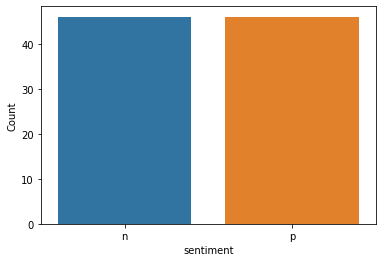

```python
sns.countplot('sentiment', data=df_snt)
_ = plt.xlabel('sentiment')
_ = plt.ylabel('Count')
plt.show()
```

```python
##Negative sentiment

dfN=pd.DataFrame(dfN)
dfN.head()
```

|  | Lie | sentiment | review |
| --- | --- | --- | --- |
| 0 | f | n | 'Mike\'s Pizza High Point NY Service was very ... |
| 1 | f | n | 'i really like this buffet restaurant in Marsh... |
| 2 | f | n | 'After I went shopping with some of my friend ... |
| 3 | f | n | 'Olive Oil Garden was very disappointing. I ex... |
| 4 | f | n | 'The Seven Heaven restaurant was never known f... |

```python
dfN.iloc[:, lambda dfN: [1, 2]]
```

|  | sentiment | review |
| --- | --- | --- |
| 0 | n | 'Mike\'s Pizza High Point NY Service was very ... |
| 1 | n | 'i really like this buffet restaurant in Marsh... |
| 2 | n | 'After I went shopping with some of my friend ... |
| 3 | n | 'Olive Oil Garden was very disappointing. I ex... |
| 4 | n | 'The Seven Heaven restaurant was never known f... |
| 5 | n | 'I went to XYZ restaurant and had a terrible e... |
| 6 | n | 'I went to ABC restaurant two days ago and I h... |
| 7 | n | 'I went to the Chilis on Erie Blvd and had the... |
| 8 | n | 'OMG. This restaurant is horrible. The recepti... |
| 9 | n | 'Yesterday I went to a casino-restaurant calle... |
| 10 | n | 'Last weekend I went to a place called Ratasti... |
| 11 | n | 'I once went to Chipotle at Marshall Street to... |
| 12 | n | 'I entered the restaurant and a waitress came ... |
| 13 | n | 'Carlo\'s Plate Shack was the worst dining exp... |
| 14 | n | 'This is the last place you would want to dine... |
| 15 | n | 'In each of the diner dish there are at least ... |
| 16 | n | 'I went there with two friends at 6pm. Long qu... |
| 17 | n | 'I had heard that Panera bread is a good place... |
| 18 | n | 'The service was way below average and we had ... |
| 19 | n | 'This place called Samarkand near to SU Main C... |
| 20 | n | 'Usually I use Yelp to find restaurant. The Ye... |
| 21 | n | 'I don\'t usually write reviews on TripAdvisor... |
| 22 | n | 'I recently ate at a restaurant called White C... |
| 23 | n | 'Pizza Hut Syracuse NY The only thing worth go... |
| 24 | n | 'the staff at this restaurant is very unfriend... |
| 25 | n | 'Friday is the worse restaurant I have ever go... |
| 26 | n | 'This diner was not at all up to par. I\'ve be... |
| 27 | n | 'The worst restaurant I have ever been to ende... |
| 28 | n | 'I went to this restaurant where I had ordered... |
| 29 | n | 'I went to XYZ restaurant last week and I was ... |
| 30 | n | 'I went to Applebees (regrettably) once and it... |
| 31 | n | 'The restaurant looked good from the outside. ... |
| 32 | n | 'Last week I went o my favorite Indian \'Thali... |
| 33 | n | 'This place used to be great. I can\'t believe... |
| 34 | n | 'I once went to a restaurant which was not ver... |
| 35 | n | 'I ordered the food and took it back home when... |
| 36 | n | 'The worst restaurant experience of my life ha... |
| 37 | n | 'The food was not bad but the place was all na... |
| 38 | n | 'The restaurant environment is bad and I can s... |
| 39 | n | 'This restaurant is quite popular recently. We... |
| 40 | n | 'We indians are craving Indian food around the... |
| 41 | n | 'After reading the reviews as well listening t... |
| 42 | n | 'Restaurant : Samrat Food Ordered : Dal Tadka ... |
| 43 | n | 'I have been to a Asian restaurant in New York... |
| 44 | n | 'The food at Lemongrass Restaurant was a mixed... |
| 45 | n | 'The worst restaurant that I have ever eaten i... |

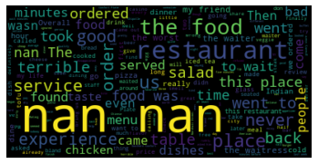

```python
# Negative sentiment
from wordcloud import WordCloud, STOPWORDS, ImageColorGenerator
N = dfN.review[0]
stopwords = set(STOPWORDS)
# Create and generate a word cloud image:
stopwords.update(["co", "https"])
wordcloud = WordCloud(stopwords=stopwords, background_color="black").generate(N)

N= " ".join(review for review in dfN.review)
# Create stopword list:

stopwords.update([ "CO", "amp", "one","Im","said","the"])


# Create and generate a word cloud image:
#wordcloud = WordCloud().generate(text)
# Generate a word cloud image
wordcloud = WordCloud(stopwords=stopwords, background_color="black").generate(N)

# Display the generated image:
plt.imshow(wordcloud, interpolation='bilinear')
plt.axis("off")
plt.show()
```

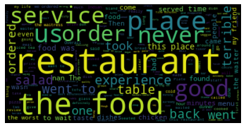

```python
from wordcloud import WordCloud, STOPWORDS, ImageColorGenerator
N = dfN.review[0]
stopwords = set(STOPWORDS)
# Create and generate a word cloud image:
stopwords.update(["co", "https"])
wordcloud = WordCloud(stopwords=stopwords, background_color="black").generate(N)

N= " ".join(review for review in dfN.review)
# Create stopword list:

stopwords.update([ "nan"])


# Create and generate a word cloud image:
#wordcloud = WordCloud().generate(text)
# Generate a word cloud image
wordcloud = WordCloud(stopwords=stopwords, background_color="black").generate(N)

# Display the generated image:
plt.imshow(wordcloud, interpolation='bilinear')
plt.axis("off")
plt.show()
```

```python
## Sentiment
def text_cleaning(dfN):
 remove_punctuation = [char for char in dfN if char not in string.punctuation]
 #print(remove_punctuation)
 remove_punctuation=''.join(remove_punctuation)
 #print(remove_punctuation)
 return [word for word in remove_punctuation.split() if word.lower() not in stopwords.words('english')]
```

```python
## Sentement
from sklearn.feature_extraction.text import CountVectorizer
bow_transformerN = CountVectorizer(analyzer=text_cleaning).fit(dfN['review'])

#print(len(bow_transformer.vocabulary_))
bow_transformerN.vocabulary_
```

[output not shown]

[output cut: 928 more lines]

[output not shown]

```python
## Semtiment Transform Neg
TrandfN = bow_transformerN.transform(dfN['review'])
DfNX = TrandfN.toarray()
print(DfNX)

DfNX.shape
```

```
[[0 0 0 ... 0 0 0]
 [0 0 0 ... 0 0 0]
 [0 0 0 ... 0 0 0]
 ...
 [0 0 0 ... 0 0 0]
 [1 0 0 ... 0 1 0]
 [0 0 0 ... 0 0 0]]
```

```
(46, 983)
```

```python
##Sentiment Neg Vect
# TF-IDF Algo -term frequency-inverse document frequency to know the most significant words
import pandas as pd
from sklearn.feature_extraction.text import TfidfTransformer
tfidf_transformerN=TfidfTransformer().fit(TrandfN)
print(tfidf_transformerN)

review_tfidfN=tfidf_transformerN.transform(TrandfN)
print(review_tfidfN)# got tfidf values for whole vocabulary
print(review_tfidfN.shape)
```

```
TfidfTransformer()
  (0, 976)	0.1708951843521961
  (0, 884)	0.1355293883282984
  (0, 856)	0.15017737468719755
  (0, 814)	0.1355293883282984
  (0, 767)	0.1000955785349972
  (0, 711)	0.1355293883282984
  (0, 691)	0.15017737468719755
  (0, 674)	0.12513647661109736
  (0, 658)	0.12513647661109736
  (0, 616)	0.722527589475914
  (0, 588)	0.15017737468719755
  (0, 582)	0.12513647661109736
  (0, 563)	0.0885909981997629
  (0, 557)	0.12513647661109736
  (0, 549)	0.15017737468719755
  (0, 475)	0.08544759217609806
  (0, 395)	0.15017737468719755
  (0, 376)	0.1000955785349972
  (0, 362)	0.11707510799918983
  (0, 318)	0.15017737468719755
  (0, 151)	0.15017737468719755
  (0, 143)	0.15017737468719755
  (0, 129)	0.15017737468719755
  (0, 127)	0.1355293883282984
  (0, 111)	0.12513647661109736
  :	:
  (45, 676)	0.10155696900273439
  (45, 675)	0.05158900966094725
  (45, 667)	0.3375996713511746
  (45, 645)	0.05798823712470188
  (45, 644)	0.13792898381138463
  (45, 616)	0.5684862785759348
  (45, 577)	0.10155696900273439
  (45, 574)	0.09376919229887128
  (45, 498)	0.09376919229887128
  (45, 470)	0.08772852339054589
  (45, 440)	0.18753838459774255
  (45, 435)	0.09376919229887128
  (45, 428)	0.11253322378372486
  (45, 406)	0.08279293751788082
  (45, 390)	0.11253322378372486
  (45, 270)	0.07861995912193089
  (45, 263)	0.10155696900273439
  (45, 255)	0.09376919229887128
  (45, 249)	0.08279293751788082
  (45, 246)	0.20311393800546879
  (45, 194)	0.08772852339054589
  (45, 186)	0.10155696900273439
  (45, 95)	0.11253322378372486
  (45, 58)	0.10155696900273439
  (45, 20)	0.11253322378372486
(46, 983)
```

```python
import numpy as np
words, values = pd.DataFrame(np.array(bow_transformerN.get_feature_names())), pd.DataFrame(np.array(TrandfN.mean(axis=0))).transpose()

# Build a dataframe with the words and tf-idf results to view words with both the highest and lowest scores.
review_tfidfN = pd.concat([words, values], axis=1)
review_tfidfN.columns = ['Words', 'tf-idf']
review_tfidfN = review_tfidfN.sort_values(by=['tf-idf'], ascending=False)


print('Neg_sent Top 10 highest frequency: ')
print(review_tfidfN.iloc[:10, :], '\n')
```

```
Neg_sent Top 10 highest frequency:
          Words     tf-idf
616         nan  18.304348
450        food   0.826087
748  restaurant   0.782609
675       place   0.630435
957        went   0.478261
605     minutes   0.456522
924          us   0.434783
645     ordered   0.369565
976       would   0.347826
475        good   0.282609
```

## Positive sentiment

```python
dfP.iloc[:, lambda dfN: [1, 2]]
```

|  | sentiment | review |
| --- | --- | --- |
| 0 | p | 'Twin Trees Cicero NY This place is very kid f... |
| 1 | p | 'i really like the food here. they have the be... |
| 2 | p | 'In my favorite restaurant Yuenan Restaurant. ... |
| 3 | p | 'This restaurant is AMAZING! I felt like life ... |
| 4 | p | 'The best experience I ever had happened in Lo... |
| 5 | p | 'I went to this ultra-luxurious restaurant in ... |
| 6 | p | 'WQR is the best! A group of us went out last ... |
| 7 | p | 'I went to Joey\'s and had the best lasagna on... |
| 8 | p | 'This restaurant ROCKS! I mean the food is gre... |
| 9 | p | 'Two days ago I went to the rooftop restaurant... |
| 10 | p | 'Cacata is the best place for Chinese food in ... |
| 11 | p | 'The best dining experience I have ever had is... |
| 12 | p | 'I went into the restaurant it decorated comfo... |
| 13 | p | 'Carlo\'s Plate Shack was amazing! The waitres... |
| 14 | p | 'This place was one of the best restaurant I h... |
| 15 | p | 'The service is good and I just felt like home... |
| 16 | p | 'This Japanese restaurant is so popular recent... |
| 17 | p | 'Hibachi the grill is one of my favorite resta... |
| 18 | p | 'Gannon’s Isle Ice Cream served the best ice c... |
| 19 | p | 'RIM KAAP One of the best Thai restaurants in ... |
| 20 | p | 'It is a France restaurant which has Michelin ... |
| 21 | p | 'It\'s hard to pick a favorite dining experien... |
| 22 | p | 'I ate at this restaurant called Banana Leaf. ... |
| 23 | p | 'Twin Trees Cicero NY HUGE salad bar and high ... |
| 24 | p | 'i really like this one chicken wings restaura... |
| 25 | p | 'Ruby Tuesday is my favorite America Style Res... |
| 26 | p | 'Stronghearts cafe is the BEST! The owners hav... |
| 27 | p | 'The best restaurant I have ever been was a sm... |
| 28 | p | 'My best restaurant is Amer Palace Hotel in my... |
| 29 | p | 'When you walk into TYU you may not have the h... |
| 30 | p | 'I went to this awesome restaurant in San Fran... |
| 31 | p | 'This cafe is located on the 2nd street from t... |
| 32 | p | 'I went to cruise dinner in NYC with Spirit Cr... |
| 33 | p | 'Halo\'s is home. I have been here numerous ti... |
| 34 | p | 'The best restaurant I have gone to is when I ... |
| 35 | p | 'The restaurant looked pretty good the people ... |
| 36 | p | ? nan nan nan nan nan nan nan nan nan nan nan ... |
| 37 | p | ? nan nan nan nan nan nan nan nan nan nan nan ... |
| 38 | p | 'A big piano is in the middle of the lobby and... |
| 39 | p | 'Can\'t say too much about it. Just try it bud... |
| 40 | p | 'Blue Monkey Cafe is my favorite Japanese rest... |
| 41 | p | 'Pastablities is a locally owned restaurant in... |
| 42 | p | 'I like the Pizza at Dominoes for their specia... |
| 43 | p | 'It was a really amazing Japanese restaurant. ... |
| 44 | p | 'How do I even pick a best experience at Joe\'... |
| 45 | p | 'My sister and I ate at this restaurant called... |

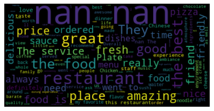

```python
from wordcloud import WordCloud, STOPWORDS, ImageColorGenerator
N = dfP.review[0]
stopwords = set(STOPWORDS)
# Create and generate a word cloud image:
stopwords.update(["co", "https"])
wordcloud = WordCloud(stopwords=stopwords, background_color="black").generate(N)

N= " ".join(review for review in dfP.review)
# Create stopword list:

stopwords.update([ "CO", "amp", "one","Im","said","the"])


# Create and generate a word cloud image:
#wordcloud = WordCloud().generate(text)
# Generate a word cloud image
wordcloud = WordCloud(stopwords=stopwords, background_color="black").generate(N)

# Display the generated image:
plt.imshow(wordcloud, interpolation='bilinear')
plt.axis("off")
plt.show()
```

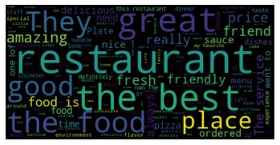

```python
from wordcloud import WordCloud, STOPWORDS, ImageColorGenerator
N = dfP.review[0]
stopwords = set(STOPWORDS)
# Create and generate a word cloud image:
stopwords.update(["co", "https"])
wordcloud = WordCloud(stopwords=stopwords, background_color="black").generate(N)

N= " ".join(review for review in dfP.review)
# Create stopword list:

stopwords.update([ "nan"])


# Create and generate a word cloud image:
#wordcloud = WordCloud().generate(text)
# Generate a word cloud image
wordcloud = WordCloud(stopwords=stopwords, background_color="black").generate(N)

# Display the generated image:
plt.imshow(wordcloud, interpolation='bilinear')
plt.axis("off")
plt.show()
```

```python
## Sentiment Positive
def text_cleaning(dfP):
 remove_punctuation = [char for char in dfP if char not in string.punctuation]
 #print(remove_punctuation)
 remove_punctuation=''.join(remove_punctuation)
 #print(remove_punctuation)
 return [word for word in remove_punctuation.split() if word.lower() not in stopwords.words('english')]

## Sentement
from sklearn.feature_extraction.text import CountVectorizer
bow_transformerP = CountVectorizer(analyzer=text_cleaning).fit(dfP['review'])

#print(len(bow_transformer.vocabulary_))
bow_transformerP.vocabulary_
```

[output not shown]

[output cut: 734 more lines]

[output not shown]

```python
## Semtiment Transform Neg
TrandfP = bow_transformerP.transform(dfN['review'])
DfNP = TrandfN.toarray()
print(DfNP)

DfNP.shape
```

```
[[0 0 0 ... 0 0 0]
 [0 0 0 ... 0 0 0]
 [0 0 0 ... 0 0 0]
 ...
 [0 0 0 ... 0 0 0]
 [1 0 0 ... 0 1 0]
 [0 0 0 ... 0 0 0]]
```

```
(46, 983)
```

```python
##Sentiment Neg Vect
# TF-IDF Algo -term frequency-inverse document frequency to know the most significant words
import pandas as pd
from sklearn.feature_extraction.text import TfidfTransformer
```

```python
tfidf_transformerP=TfidfTransformer().fit(TrandfP)
print(tfidf_transformerP)

review_tfidfP=tfidf_transformerP.transform(TrandfP)
print(review_tfidfP)# got tfidf values for whole vocabulary
print(review_tfidfP.shape)
```

```
TfidfTransformer()
  (0, 786)	0.1997885819370505
  (0, 711)	0.15844345999301776
  (0, 689)	0.17556799415687419
  (0, 627)	0.11701882513238164
  (0, 596)	0.15844345999301776
  (0, 570)	0.1462934096446279
  (0, 520)	0.8446859579980506
  (0, 469)	0.10356915538498598
  (0, 458)	0.17556799415687419
  (0, 413)	0.09989429096852526
  (0, 333)	0.11701882513238164
  (0, 327)	0.13686909842398137
  (0, 114)	0.15844345999301776
  (0, 102)	0.1462934096446279
  (1, 687)	0.1585460735708497
  (1, 676)	0.1235991688149886
  (1, 617)	0.11578729501319793
  (1, 606)	0.10567344775856778
  (1, 602)	0.13210976066470875
  (1, 520)	0.7627907505815691
  (1, 484)	0.1430818218634265
  (1, 469)	0.09352776972929736
  (1, 394)	0.1585460735708497
  (1, 333)	0.10567344775856778
  (1, 325)	0.13210976066470875
  :	:
  (44, 21)	0.0830032743110588
  (44, 0)	0.07663826585943184
  (45, 758)	0.09637271075240825
  (45, 712)	0.12048225947163335
  (45, 696)	0.08861116966463406
  (45, 666)	0.28918361638171697
  (45, 617)	0.05279819920612914
  (45, 614)	0.260977252561604
  (45, 590)	0.14459180819085848
  (45, 572)	0.06628574156897868
  (45, 542)	0.0745079877545776
  (45, 541)	0.17722233932926812
  (45, 520)	0.7304372538812354
  (45, 484)	0.130488626280802
  (45, 482)	0.12048225947163335
  (45, 426)	0.12048225947163335
  (45, 405)	0.11272071838385916
  (45, 383)	0.2409645189432667
  (45, 380)	0.12048225947163335
  (45, 354)	0.10637907756157688
  (45, 238)	0.10101729664457934
  (45, 222)	0.12048225947163335
  (45, 172)	0.11272071838385916
  (45, 164)	0.130488626280802
  (45, 17)	0.14459180819085848
(46, 789)
```

```python
import numpy as np
words, values = pd.DataFrame(np.array(bow_transformerN.get_feature_names())), pd.DataFrame(np.array(TrandfP.mean(axis=0))).transpose()

# Build a dataframe with the words and tf-idf results to view words with both the highest and lowest scores.
review_tfidfP = pd.concat([words, values], axis=1)
review_tfidfP.columns = ['Words', 'tf-idf']
review_tfidfP = review_tfidfP.sort_values(by=['tf-idf'], ascending=False)


print('Pos_sent Top 10 highest frequency: ')
print(review_tfidfP.iloc[:10, :], '\n')
```

[output not shown]

## Lie Detection False

```python
dfF.iloc[:, lambda dfN: [0, 2]]
```

|  | Lie | review |
| --- | --- | --- |
| 0 | f | 'Mike\'s Pizza High Point NY Service was very ... |
| 1 | f | 'i really like this buffet restaurant in Marsh... |
| 2 | f | 'After I went shopping with some of my friend ... |
| 3 | f | 'Olive Oil Garden was very disappointing. I ex... |
| 4 | f | 'The Seven Heaven restaurant was never known f... |
| 5 | f | 'I went to XYZ restaurant and had a terrible e... |
| 6 | f | 'I went to ABC restaurant two days ago and I h... |
| 7 | f | 'I went to the Chilis on Erie Blvd and had the... |
| 8 | f | 'OMG. This restaurant is horrible. The recepti... |
| 9 | f | 'Yesterday I went to a casino-restaurant calle... |
| 10 | f | 'Last weekend I went to a place called Ratasti... |
| 11 | f | 'I once went to Chipotle at Marshall Street to... |
| 12 | f | 'I entered the restaurant and a waitress came ... |
| 13 | f | 'Carlo\'s Plate Shack was the worst dining exp... |
| 14 | f | 'This is the last place you would want to dine... |
| 15 | f | 'In each of the diner dish there are at least ... |
| 16 | f | 'I went there with two friends at 6pm. Long qu... |
| 17 | f | 'I had heard that Panera bread is a good place... |
| 18 | f | 'The service was way below average and we had ... |
| 19 | f | 'This place called Samarkand near to SU Main C... |
| 20 | f | 'Usually I use Yelp to find restaurant. The Ye... |
| 21 | f | 'I don\'t usually write reviews on TripAdvisor... |
| 22 | f | 'I recently ate at a restaurant called White C... |
| 23 | f | 'Twin Trees Cicero NY This place is very kid f... |
| 24 | f | 'i really like the food here. they have the be... |
| 25 | f | 'In my favorite restaurant Yuenan Restaurant. ... |
| 26 | f | 'This restaurant is AMAZING! I felt like life ... |
| 27 | f | 'The best experience I ever had happened in Lo... |
| 28 | f | 'I went to this ultra-luxurious restaurant in ... |
| 29 | f | 'WQR is the best! A group of us went out last ... |
| 30 | f | 'I went to Joey\'s and had the best lasagna on... |
| 31 | f | 'This restaurant ROCKS! I mean the food is gre... |
| 32 | f | 'Two days ago I went to the rooftop restaurant... |
| 33 | f | 'Cacata is the best place for Chinese food in ... |
| 34 | f | 'The best dining experience I have ever had is... |
| 35 | f | 'I went into the restaurant it decorated comfo... |
| 36 | f | 'Carlo\'s Plate Shack was amazing! The waitres... |
| 37 | f | 'This place was one of the best restaurant I h... |
| 38 | f | 'The service is good and I just felt like home... |
| 39 | f | 'This Japanese restaurant is so popular recent... |
| 40 | f | 'Hibachi the grill is one of my favorite resta... |
| 41 | f | 'Gannon’s Isle Ice Cream served the best ice c... |
| 42 | f | 'RIM KAAP One of the best Thai restaurants in ... |
| 43 | f | 'It is a France restaurant which has Michelin ... |
| 44 | f | 'It\'s hard to pick a favorite dining experien... |
| 45 | f | 'I ate at this restaurant called Banana Leaf. ... |

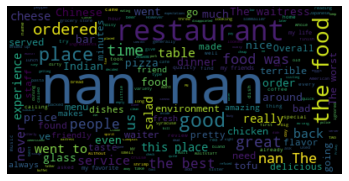

```python
from wordcloud import WordCloud, STOPWORDS, ImageColorGenerator
N = dfF.review[0]
stopwords = set(STOPWORDS)
# Create and generate a word cloud image:
stopwords.update(["co", "https"])
wordcloud = WordCloud(stopwords=stopwords, background_color="black").generate(N)

N= " ".join(review for review in dfF.review)
# Create stopword list:

stopwords.update([ "CO", "amp", "one","Im","said","the"])


# Create and generate a word cloud image:
#wordcloud = WordCloud().generate(text)
# Generate a word cloud image
wordcloud = WordCloud(stopwords=stopwords, background_color="black").generate(N)

# Display the generated image:
plt.imshow(wordcloud, interpolation='bilinear')
plt.axis("off")
plt.show()
```

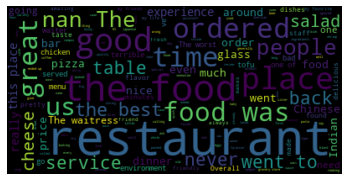

```python
N = dfF.review[0]
stopwords = set(STOPWORDS)
# Create and generate a word cloud image:
stopwords.update(["co", "https"])
wordcloud = WordCloud(stopwords=stopwords, background_color="black").generate(N)

N= " ".join(review for review in dfF.review)
# Create stopword list:

stopwords.update([ "nan"])


# Create and generate a word cloud image:
#wordcloud = WordCloud().generate(text)
# Generate a word cloud image
wordcloud = WordCloud(stopwords=stopwords, background_color="black").generate(N)

# Display the generated image:
plt.imshow(wordcloud, interpolation='bilinear')
plt.axis("off")
plt.show()
```

```python
## Lie Detection False
def text_cleaning(dfF):
 remove_punctuation = [char for char in dfF if char not in string.punctuation]
 #print(remove_punctuation)
 remove_punctuation=''.join(remove_punctuation)
 #print(remove_punctuation)
 return [word for word in remove_punctuation.split() if word.lower() not in stopwords.words('english')]
```

```python
## Lie Detection False
from sklearn.feature_extraction.text import CountVectorizer
bow_transformerF = CountVectorizer(analyzer=text_cleaning).fit(dfF['review'])

#print(len(bow_transformer.vocabulary_))
bow_transformerF.vocabulary_
```

```python
## Lie Detection False
TrandfF = bow_transformerN.transform(dfF['review'])
DfNXF = TrandfF.toarray()
print(DfNXF)

DfNXF.shape
```

```
[[0 0 0 ... 0 0 0]
 [0 0 0 ... 0 0 0]
 [0 0 0 ... 0 0 0]
 ...
 [0 0 0 ... 0 0 0]
 [0 0 0 ... 0 0 0]
 [0 0 0 ... 0 0 0]]
```

```
(46, 983)
```

```python
#### Lie Detection False
# TF-IDF Algo -term frequency-inverse document frequency to know the most significant words
import pandas as pd
from sklearn.feature_extraction.text import TfidfTransformer
tfidf_transformerF=TfidfTransformer().fit(TrandfF)
print(tfidf_transformerF)

review_tfidfF=tfidf_transformerN.transform(TrandfF)
print(review_tfidfF)# got tfidf values for whole vocabulary
print(review_tfidfF.shape)
```

```
TfidfTransformer()
  (0, 975)	0.1263312346401822
  (0, 882)	0.1263312346401822
  (0, 793)	0.08626341502474381
  (0, 784)	0.1368233741369721
  (0, 767)	0.10105125508406804
  (0, 674)	0.1263312346401822
  (0, 616)	0.7658973239269854
  (0, 584)	0.15161121419629636
  (0, 582)	0.1263312346401822
  (0, 473)	0.1181928989828909
  (0, 414)	0.15161121419629636
  (0, 366)	0.1263312346401822
  (0, 345)	0.15161121419629636
  (0, 340)	0.15161121419629636
  (0, 233)	0.15161121419629636
  (0, 229)	0.1368233741369721
  (0, 167)	0.15161121419629636
  (0, 156)	0.15161121419629636
  (0, 154)	0.15161121419629636
  (0, 127)	0.1368233741369721
  (0, 111)	0.1263312346401822
  (0, 82)	0.15161121419629636
  (0, 67)	0.15161121419629636
  (1, 941)	0.108460614663131
  (1, 935)	0.10384994136636078
  :	:
  (44, 378)	0.11535040602855616
  (44, 276)	0.09611663152414615
  (44, 241)	0.1922332630482923
  (44, 224)	0.0736145578593332
  (44, 209)	0.11535040602855616
  (44, 154)	0.11535040602855616
  (44, 89)	0.1922332630482923
  (44, 43)	0.5204968459807483
  (44, 23)	0.10409936919614965
  (45, 976)	0.08664071447219285
  (45, 900)	0.15227433224381318
  (45, 772)	0.30454866448762635
  (45, 748)	0.11120699890794286
  (45, 732)	0.13742181304001327
  (45, 725)	0.10149323367599272
  (45, 722)	0.15227433224381318
  (45, 645)	0.2354003499392399
  (45, 616)	0.8058780298215698
  (45, 573)	0.15227433224381318
  (45, 437)	0.11203126375610305
  (45, 416)	0.08982801252039578
  (45, 406)	0.11203126375610305
  (45, 270)	0.10638459802179184
  (45, 241)	0.12688378295990294
  (45, 212)	0.15227433224381318
(46, 983)
```

```python
## Lie Detection False
import numpy as np
words, values = pd.DataFrame(np.array(bow_transformerN.get_feature_names())), pd.DataFrame(np.array(TrandfF.mean(axis=0))).transpose()

# Build a dataframe with the words and tf-idf results to view words with both the highest and lowest scores.
review_tfidfF = pd.concat([words, values], axis=1)
review_tfidfF.columns = ['Words', 'tf-idf']
review_tfidfF = review_tfidfF.sort_values(by=['tf-idf'], ascending=False)


print('False Lie Dete Top 10 highest freq: ')
print(review_tfidfF.iloc[:10, :], '\n')
```

```
False Lie Dete Top 10 highest freq:
          Words     tf-idf
616         nan  19.217391
748  restaurant   0.847826
450        food   0.847826
675       place   0.521739
475        good   0.391304
957        went   0.326087
241        best   0.260870
645     ordered   0.260870
640         one   0.239130
481       great   0.217391
```

## Lie Detection True

```python
dfT.iloc[:, lambda dfN: [0, 2]]
```

|  | Lie | review |
| --- | --- | --- |
| 0 | t | 'Pizza Hut Syracuse NY The only thing worth go... |
| 1 | t | 'the staff at this restaurant is very unfriend... |
| 2 | t | 'Friday is the worse restaurant I have ever go... |
| 3 | t | 'This diner was not at all up to par. I\'ve be... |
| 4 | t | 'The worst restaurant I have ever been to ende... |
| 5 | t | 'I went to this restaurant where I had ordered... |
| 6 | t | 'I went to XYZ restaurant last week and I was ... |
| 7 | t | 'I went to Applebees (regrettably) once and it... |
| 8 | t | 'The restaurant looked good from the outside. ... |
| 9 | t | 'Last week I went o my favorite Indian \'Thali... |
| 10 | t | 'This place used to be great. I can\'t believe... |
| 11 | t | 'I once went to a restaurant which was not ver... |
| 12 | t | 'I ordered the food and took it back home when... |
| 13 | t | 'The worst restaurant experience of my life ha... |
| 14 | t | 'The food was not bad but the place was all na... |
| 15 | t | 'The restaurant environment is bad and I can s... |
| 16 | t | 'This restaurant is quite popular recently. We... |
| 17 | t | 'We indians are craving Indian food around the... |
| 18 | t | 'After reading the reviews as well listening t... |
| 19 | t | 'Restaurant : Samrat Food Ordered : Dal Tadka ... |
| 20 | t | 'I have been to a Asian restaurant in New York... |
| 21 | t | 'The food at Lemongrass Restaurant was a mixed... |
| 22 | t | 'The worst restaurant that I have ever eaten i... |
| 23 | t | 'Twin Trees Cicero NY HUGE salad bar and high ... |
| 24 | t | 'i really like this one chicken wings restaura... |
| 25 | t | 'Ruby Tuesday is my favorite America Style Res... |
| 26 | t | 'Stronghearts cafe is the BEST! The owners hav... |
| 27 | t | 'The best restaurant I have ever been was a sm... |
| 28 | t | 'My best restaurant is Amer Palace Hotel in my... |
| 29 | t | 'When you walk into TYU you may not have the h... |
| 30 | t | 'I went to this awesome restaurant in San Fran... |
| 31 | t | 'This cafe is located on the 2nd street from t... |
| 32 | t | 'I went to cruise dinner in NYC with Spirit Cr... |
| 33 | t | 'Halo\'s is home. I have been here numerous ti... |
| 34 | t | 'The best restaurant I have gone to is when I ... |
| 35 | t | 'The restaurant looked pretty good the people ... |
| 36 | t | ? nan nan nan nan nan nan nan nan nan nan nan ... |
| 37 | t | ? nan nan nan nan nan nan nan nan nan nan nan ... |
| 38 | t | 'A big piano is in the middle of the lobby and... |
| 39 | t | 'Can\'t say too much about it. Just try it bud... |
| 40 | t | 'Blue Monkey Cafe is my favorite Japanese rest... |
| 41 | t | 'Pastablities is a locally owned restaurant in... |
| 42 | t | 'I like the Pizza at Dominoes for their specia... |
| 43 | t | 'It was a really amazing Japanese restaurant. ... |
| 44 | t | 'How do I even pick a best experience at Joe\'... |
| 45 | t | 'My sister and I ate at this restaurant called... |

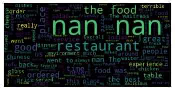

```python
from wordcloud import WordCloud, STOPWORDS, ImageColorGenerator
N = dfT.review[0]
stopwords = set(STOPWORDS)
# Create and generate a word cloud image:
stopwords.update(["co", "https"])
wordcloud = WordCloud(stopwords=stopwords, background_color="black").generate(N)

N= " ".join(review for review in dfT.review)
# Create stopword list:

stopwords.update([ "CO", "amp", "one","Im","said","the"])


# Create and generate a word cloud image:
#wordcloud = WordCloud().generate(text)
# Generate a word cloud image
wordcloud = WordCloud(stopwords=stopwords, background_color="black").generate(N)

# Display the generated image:
plt.imshow(wordcloud, interpolation='bilinear')
plt.axis("off")
plt.show()
```

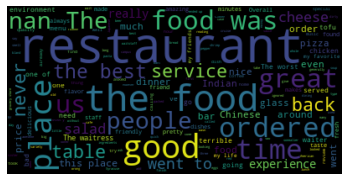

```python
from wordcloud import WordCloud, STOPWORDS, ImageColorGenerator
N = dfT.review[0]
stopwords = set(STOPWORDS)
# Create and generate a word cloud image:
stopwords.update(["co", "https"])
wordcloud = WordCloud(stopwords=stopwords, background_color="black").generate(N)

N= " ".join(review for review in dfT.review)
# Create stopword list:

stopwords.update([ "nan"])


# Create and generate a word cloud image:
#wordcloud = WordCloud().generate(text)
# Generate a word cloud image
wordcloud = WordCloud(stopwords=stopwords, background_color="black").generate(N)

# Display the generated image:
plt.imshow(wordcloud, interpolation='bilinear')
plt.axis("off")
plt.show()
```

```python
## Sentiment
def text_cleaning(dfT):
 remove_punctuation = [char for char in dfN if char not in string.punctuation]
 #print(remove_punctuation)
 remove_punctuation=''.join(remove_punctuation)
 #print(remove_punctuation)
 return [word for word in remove_punctuation.split() if word.lower() not in stopwords.words('english')]
```

```python
from sklearn.feature_extraction.text import CountVectorizer
bow_transformerT = CountVectorizer(analyzer=text_cleaning).fit(dfT['review'])

#print(len(bow_transformer.vocabulary_))
bow_transformerN.vocabulary_
```

[output not shown]

[output cut: 928 more lines]

[output not shown]

```python
TrandfT = bow_transformerN.transform(dfF['review'])
DfNX = TrandfF.toarray()
print(DfNX)

DfNX.shape
```

```
[[0 0 0 ... 0 0 0]
 [0 0 0 ... 0 0 0]
 [0 0 0 ... 0 0 0]
 ...
 [0 0 0 ... 0 0 0]
 [0 0 0 ... 0 0 0]
 [0 0 0 ... 0 0 0]]
```

```
(46, 983)
```

```python
##Sentiment Neg Vect
# TF-IDF Algo -term frequency-inverse document frequency to know the most significant words
import pandas as pd
from sklearn.feature_extraction.text import TfidfTransformer
tfidf_transformerT=TfidfTransformer().fit(TrandfT)
print(tfidf_transformerT)

review_tfidfT=tfidf_transformerN.transform(TrandfN)
print(review_tfidfT)# got tfidf values for whole vocabulary
print(review_tfidfT.shape)
```

```
TfidfTransformer()
  (0, 976)	0.1708951843521961
  (0, 884)	0.1355293883282984
  (0, 856)	0.15017737468719755
  (0, 814)	0.1355293883282984
  (0, 767)	0.1000955785349972
  (0, 711)	0.1355293883282984
  (0, 691)	0.15017737468719755
  (0, 674)	0.12513647661109736
  (0, 658)	0.12513647661109736
  (0, 616)	0.722527589475914
  (0, 588)	0.15017737468719755
  (0, 582)	0.12513647661109736
  (0, 563)	0.0885909981997629
  (0, 557)	0.12513647661109736
  (0, 549)	0.15017737468719755
  (0, 475)	0.08544759217609806
  (0, 395)	0.15017737468719755
  (0, 376)	0.1000955785349972
  (0, 362)	0.11707510799918983
  (0, 318)	0.15017737468719755
  (0, 151)	0.15017737468719755
  (0, 143)	0.15017737468719755
  (0, 129)	0.15017737468719755
  (0, 127)	0.1355293883282984
  (0, 111)	0.12513647661109736
  :	:
  (45, 676)	0.10155696900273439
  (45, 675)	0.05158900966094725
  (45, 667)	0.3375996713511746
  (45, 645)	0.05798823712470188
  (45, 644)	0.13792898381138463
  (45, 616)	0.5684862785759348
  (45, 577)	0.10155696900273439
  (45, 574)	0.09376919229887128
  (45, 498)	0.09376919229887128
  (45, 470)	0.08772852339054589
  (45, 440)	0.18753838459774255
  (45, 435)	0.09376919229887128
  (45, 428)	0.11253322378372486
  (45, 406)	0.08279293751788082
  (45, 390)	0.11253322378372486
  (45, 270)	0.07861995912193089
  (45, 263)	0.10155696900273439
  (45, 255)	0.09376919229887128
  (45, 249)	0.08279293751788082
  (45, 246)	0.20311393800546879
  (45, 194)	0.08772852339054589
  (45, 186)	0.10155696900273439
  (45, 95)	0.11253322378372486
  (45, 58)	0.10155696900273439
  (45, 20)	0.11253322378372486
(46, 983)
```

```python
import numpy as np
words, values = pd.DataFrame(np.array(bow_transformerN.get_feature_names())), pd.DataFrame(np.array(TrandfT.mean(axis=0))).transpose()

# Build a dataframe with the words and tf-idf results to view words with both the highest and lowest scores.
review_tfidfT = pd.concat([words, values], axis=1)
review_tfidfT.columns = ['Words', 'tf-idf']
review_tfidfT = review_tfidfT.sort_values(by=['tf-idf'], ascending=False)


print('True Lie Detec Top 10 highest frequency: ')
print(review_tfidfT.iloc[:10, :], '\n')
```

```
True Lie Detec Top 10 highest frequency:
          Words     tf-idf
616         nan  19.217391
748  restaurant   0.847826
450        food   0.847826
675       place   0.521739
475        good   0.391304
957        went   0.326087
241        best   0.260870
645     ordered   0.260870
640         one   0.239130
481       great   0.217391
```

## All Data Lie Detection

```python
##Lie Detection
df_d = df_snt
df_d.loc[:, ['lie', 'review']]
```

|  | lie | review |
| --- | --- | --- |
| 0 | f | 'Mike\'s Pizza High Point NY Service was very ... |
| 1 | f | 'i really like this buffet restaurant in Marsh... |
| 2 | f | 'After I went shopping with some of my friend ... |
| 3 | f | 'Olive Oil Garden was very disappointing. I ex... |
| 4 | f | 'The Seven Heaven restaurant was never known f... |
| ... | ... | ... |
| 87 | t | 'Pastablities is a locally owned restaurant in... |
| 88 | t | 'I like the Pizza at Dominoes for their specia... |
| 89 | t | 'It was a really amazing Japanese restaurant. ... |
| 90 | t | 'How do I even pick a best experience at Joe\'... |
| 91 | t | 'My sister and I ate at this restaurant called... |

92 rows × 2 columns

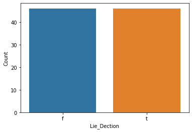

```python
sns.countplot('lie', data=df_d)
_ = plt.xlabel('Lie_Dection')
_ = plt.ylabel('Count')
plt.show()
```

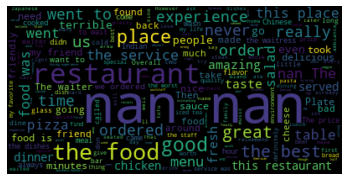

```python
from wordcloud import WordCloud, STOPWORDS, ImageColorGenerator
N = df_d.review[0]
stopwords = set(STOPWORDS)
# Create and generate a word cloud image:
stopwords.update(["co", "https"])
wordcloud = WordCloud(stopwords=stopwords, background_color="black").generate(N)

N= " ".join(review for review in df_d.review)
# Create stopword list:

stopwords.update([ "CO", "amp", "one","Im","said","the"])


# Create and generate a word cloud image:
#wordcloud = WordCloud().generate(text)
# Generate a word cloud image
wordcloud = WordCloud(stopwords=stopwords, background_color="black").generate(N)

# Display the generated image:
plt.imshow(wordcloud, interpolation='bilinear')
plt.axis("off")
plt.show()
```

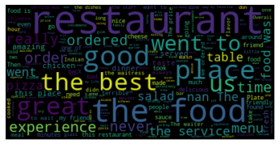

```python
## Lie detection without nan

from wordcloud import WordCloud, STOPWORDS, ImageColorGenerator
N = df_d.review[0]
stopwords = set(STOPWORDS)
# Create and generate a word cloud image:
stopwords.update(["co", "https"])
wordcloud = WordCloud(stopwords=stopwords, background_color="black").generate(N)

N= " ".join(review for review in df_d.review)
# Create stopword list:

stopwords.update([ "nan"])


# Create and generate a word cloud image:
#wordcloud = WordCloud().generate(text)
# Generate a word cloud image
wordcloud = WordCloud(stopwords=stopwords, background_color="black").generate(N)

# Display the generated image:
plt.imshow(wordcloud, interpolation='bilinear')
plt.axis("off")
plt.show()
```

## Sentiment

```python
##Sentiment
df_snt = df_snt
df_snt.loc[:, ['sentiment', 'review']]
```

|  | sentiment | review |
| --- | --- | --- |
| 0 | n | 'Mike\'s Pizza High Point NY Service was very ... |
| 1 | n | 'i really like this buffet restaurant in Marsh... |
| 2 | n | 'After I went shopping with some of my friend ... |
| 3 | n | 'Olive Oil Garden was very disappointing. I ex... |
| 4 | n | 'The Seven Heaven restaurant was never known f... |
| ... | ... | ... |
| 87 | p | 'Pastablities is a locally owned restaurant in... |
| 88 | p | 'I like the Pizza at Dominoes for their specia... |
| 89 | p | 'It was a really amazing Japanese restaurant. ... |
| 90 | p | 'How do I even pick a best experience at Joe\'... |
| 91 | p | 'My sister and I ate at this restaurant called... |

92 rows × 2 columns

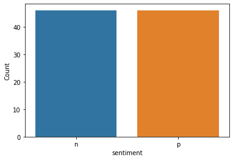

```python
sns.countplot('sentiment', data=df_d)
_ = plt.xlabel('sentiment')
_ = plt.ylabel('Count')
plt.show()
```

## Sentiment word cloud

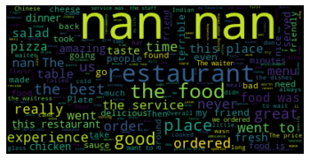

```python
from wordcloud import WordCloud, STOPWORDS, ImageColorGenerator
N = df_snt.review[0]
stopwords = set(STOPWORDS)
# Create and generate a word cloud image:
stopwords.update(["co", "https"])
wordcloud = WordCloud(stopwords=stopwords, background_color="black").generate(N)

N= " ".join(review for review in df_snt.review)
# Create stopword list:

stopwords.update([ "CO", "amp", "one","Im","said","the"])


# Create and generate a word cloud image:
#wordcloud = WordCloud().generate(text)
# Generate a word cloud image
wordcloud = WordCloud(stopwords=stopwords, background_color="black").generate(N)

# Display the generated image:
plt.imshow(wordcloud, interpolation='bilinear')
plt.axis("off")
plt.show()
```

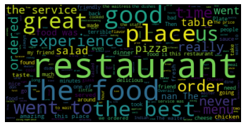

```python
from wordcloud import WordCloud, STOPWORDS, ImageColorGenerator
N = df_snt.review[0]
stopwords = set(STOPWORDS)
# Create and generate a word cloud image:
stopwords.update(["co", "https"])
wordcloud = WordCloud(stopwords=stopwords, background_color="black").generate(N)

N= " ".join(review for review in df_snt.review)
# Create stopword list:

stopwords.update([ "nan"])


# Create and generate a word cloud image:
#wordcloud = WordCloud().generate(text)
# Generate a word cloud image
wordcloud = WordCloud(stopwords=stopwords, background_color="black").generate(N)

# Display the generated image:
plt.imshow(wordcloud, interpolation='bilinear')
plt.axis("off")
plt.show()
```

## Data Cleaning

```python
## Sentiment
def text_cleaning(df_snt):
 remove_punctuation = [char for char in df_snt if char not in string.punctuation]
 #print(remove_punctuation)
 remove_punctuation=''.join(remove_punctuation)
 #print(remove_punctuation)
 return [word for word in remove_punctuation.split() if word.lower() not in stopwords.words('english')]
```

## Vectorize Sentiment

```python
## Sentement
from sklearn.feature_extraction.text import CountVectorizer
bow_transformer_snt = CountVectorizer(analyzer=text_cleaning).fit(df_snt['review'])

#print(len(bow_transformer.vocabulary_))
bow_transformer_snt.vocabulary_
```

[output not shown]

[output cut: 946 more lines]

[output not shown]

## Lie Detection

```python
## Lie Dectection
def text_cleaning(df_d):
 remove_punctuation = [char for char in df_d if char not in string.punctuation]
 #print(remove_punctuation)
 remove_punctuation=''.join(remove_punctuation)
 #print(remove_punctuation)
 return [word for word in remove_punctuation.split() if word.lower() not in stopwords.words('english')]

## Vocab
from sklearn.feature_extraction.text import CountVectorizer
bow_transformer_d = CountVectorizer(analyzer=text_cleaning).fit(df_d['review'])

#print(len(bow_transformer.vocabulary_))
bow_transformer_d.vocabulary_
```

[output not shown]

[output cut: 946 more lines]

[output not shown]

## into Array

```python
## Semtiment
Trandf_N = bow_transformer_snt.transform(df_snt['review'])
Df_snt = Trandf_N.toarray()
print(Df_snt)

Df_snt.shape
```

```
[[0 0 0 ... 0 0 0]
 [0 0 0 ... 0 0 0]
 [0 0 0 ... 0 0 0]
 ...
 [0 0 0 ... 0 0 0]
 [0 0 0 ... 0 0 0]
 [0 0 0 ... 0 0 0]]
```

```
(92, 1471)
```

```python
## Semtiment
Trandf_D = bow_transformer_d.transform(df_snt['review'])
Df_D = Trandf_D.toarray()
print(Df_D)

Df_D.shape
```

```
[[0 0 0 ... 0 0 0]
 [0 0 0 ... 0 0 0]
 [0 0 0 ... 0 0 0]
 ...
 [0 0 0 ... 0 0 0]
 [0 0 0 ... 0 0 0]
 [0 0 0 ... 0 0 0]]
```

```
(92, 1471)
```

## TF*IDF* Sentiment

```python
##Sentiment
# TF-IDF Algo -term frequency-inverse document frequency to know the most significant words
import pandas as pd
from sklearn.feature_extraction.text import TfidfTransformer
tfidf_transformer_snt=TfidfTransformer().fit(Trandf_N)
print(tfidf_transformer_snt)

review_tfidfN=tfidf_transformer_snt.transform(Trandf_N)
print(review_tfidfN)# got tfidf values for whole vocabulary
print(review_tfidfN.shape)
```

```
TfidfTransformer()
  (0, 1463)	0.18414624606537516
  (0, 1330)	0.13381477082095028
  (0, 1292)	0.15123847677016705
  (0, 1226)	0.15123847677016705
  (0, 1162)	0.10692134856228928
  (0, 1091)	0.11376600753726478
  (0, 1066)	0.16506845022424027
  (0, 1040)	0.12759598099133798
  (0, 1013)	0.14142595444541123
  (0, 949)	0.6821782282870983
  (0, 906)	0.16506845022424027
  (0, 899)	0.14142595444541123
  (0, 868)	0.08486559987574518
  (0, 861)	0.14142595444541123
  (0, 849)	0.14142595444541123
  (0, 748)	0.07758081980827813
  (0, 638)	0.16506845022424027
  (0, 614)	0.10122331558710719
  (0, 596)	0.10692134856228928
  (0, 518)	0.16506845022424027
  (0, 255)	0.16506845022424027
  (0, 240)	0.16506845022424027
  (0, 217)	0.16506845022424027
  (0, 215)	0.14142595444541123
  (0, 191)	0.12759598099133798
  :	:
  (91, 1000)	0.24806272097166385
  (91, 989)	0.19130238025623356
  (91, 949)	0.5638427149261613
  (91, 914)	0.12403136048583192
  (91, 913)	0.12403136048583192
  (91, 887)	0.11363960833294387
  (91, 856)	0.11363960833294387
  (91, 749)	0.12403136048583192
  (91, 703)	0.10626654284354402
  (91, 698)	0.09192402988058712
  (91, 669)	0.06376746008541119
  (91, 655)	0.07605854133906409
  (91, 516)	0.12403136048583192
  (91, 444)	0.08548303853776794
  (91, 409)	0.12403136048583192
  (91, 396)	0.05929891975976194
  (91, 386)	0.12403136048583192
  (91, 352)	0.09587479069065598
  (91, 339)	0.12403136048583192
  (91, 327)	0.10054754894394087
  (91, 326)	0.08034000627706339
  (91, 319)	0.12403136048583192
  (91, 210)	0.11363960833294387
  (91, 185)	0.24806272097166385
  (91, 29)	0.12403136048583192
(92, 1471)
```

## All_data_Lie Detection TF-IDF

```python
##Lie Detection
# TF-IDF Algo -term frequency-inverse document frequency to know the most significant words
import pandas as pd
from sklearn.feature_extraction.text import TfidfTransformer
tfidf_transformer_D=TfidfTransformer().fit(Trandf_D)
print(tfidf_transformer_D)

review_tfidfT=tfidf_transformer_D.transform(Trandf_N)
print(review_tfidfT)# got tfidf values for whole vocabulary
print(review_tfidfT.shape)
```

```
TfidfTransformer()
  (0, 1463)	0.18414624606537516
  (0, 1330)	0.13381477082095028
  (0, 1292)	0.15123847677016705
  (0, 1226)	0.15123847677016705
  (0, 1162)	0.10692134856228928
  (0, 1091)	0.11376600753726478
  (0, 1066)	0.16506845022424027
  (0, 1040)	0.12759598099133798
  (0, 1013)	0.14142595444541123
  (0, 949)	0.6821782282870983
  (0, 906)	0.16506845022424027
  (0, 899)	0.14142595444541123
  (0, 868)	0.08486559987574518
  (0, 861)	0.14142595444541123
  (0, 849)	0.14142595444541123
  (0, 748)	0.07758081980827813
  (0, 638)	0.16506845022424027
  (0, 614)	0.10122331558710719
  (0, 596)	0.10692134856228928
  (0, 518)	0.16506845022424027
  (0, 255)	0.16506845022424027
  (0, 240)	0.16506845022424027
  (0, 217)	0.16506845022424027
  (0, 215)	0.14142595444541123
  (0, 191)	0.12759598099133798
  :	:
  (91, 1000)	0.24806272097166385
  (91, 989)	0.19130238025623356
  (91, 949)	0.5638427149261613
  (91, 914)	0.12403136048583192
  (91, 913)	0.12403136048583192
  (91, 887)	0.11363960833294387
  (91, 856)	0.11363960833294387
  (91, 749)	0.12403136048583192
  (91, 703)	0.10626654284354402
  (91, 698)	0.09192402988058712
  (91, 669)	0.06376746008541119
  (91, 655)	0.07605854133906409
  (91, 516)	0.12403136048583192
  (91, 444)	0.08548303853776794
  (91, 409)	0.12403136048583192
  (91, 396)	0.05929891975976194
  (91, 386)	0.12403136048583192
  (91, 352)	0.09587479069065598
  (91, 339)	0.12403136048583192
  (91, 327)	0.10054754894394087
  (91, 326)	0.08034000627706339
  (91, 319)	0.12403136048583192
  (91, 210)	0.11363960833294387
  (91, 185)	0.24806272097166385
  (91, 29)	0.12403136048583192
(92, 1471)
```

```python
##sentiment
import numpy as np
words, values = pd.DataFrame(np.array(bow_transformer_snt.get_feature_names())), pd.DataFrame(np.array(Trandf_N.mean(axis=0))).transpose()

# Build a dataframe with the words and tf-idf results to view words with both the highest and lowest scores.
review_tfidf_snt = pd.concat([words, values], axis=1)
review_tfidf_snt.columns = ['Words', 'tf-idf']
review_tfidf_snt = review_tfidf_snt.sort_values(by=['tf-idf'], ascending=False)


print('All_Sent Top 10 highest frequency: ')
print(review_tfidf_snt.iloc[:10, :], '\n')

##print('Bottom 5 lowest frequency: ')
##print(review_tfidf_snt.iloc[1466:, :])
```

```
All_Sent Top 10 highest frequency:
           Words     tf-idf
949          nan  19.130435
714         food   0.815217
1136  restaurant   0.760870
1042       place   0.467391
1435        went   0.347826
396         best   0.326087
748         good   0.315217
1195     service   0.293478
989      ordered   0.282609
1387          us   0.271739
```

## Top 10 highest frequency Lie Detection

```python
# All data Lie Detection
import numpy as np
words, values = pd.DataFrame(np.array(bow_transformer_d.get_feature_names())), pd.DataFrame(np.array(Trandf_D.mean(axis=0))).transpose()

# Build a dataframe with the words and tf-idf results to view words with both the highest and lowest scores.
review_tfidf_D = pd.concat([words, values], axis=1)
review_tfidf_D.columns = ['Words', 'tf-idf']
review_tfidf_D = review_tfidf_D.sort_values(by=['tf-idf'], ascending=False)


print('all_Lie_dec Top 10 highest frequency: ')
print(review_tfidf_D.iloc[:10, :], '\n')

##print('Bottom 5 lowest frequency: ')
##print(review_tfidf_D.iloc[1466:, :])
```

```
all_Lie_dec Top 10 highest frequency:
           Words     tf-idf
949          nan  19.130435
714         food   0.815217
1136  restaurant   0.760870
1042       place   0.467391
1435        went   0.347826
396         best   0.326087
748         good   0.315217
1195     service   0.293478
989      ordered   0.282609
1387          us   0.271739
```

```python
#Function to get Subjectivity
def getSubjectivity(text):
    return TextBlob(text).sentiment.subjectivity

#Function to get Polarity
def getpolarity(text):
    return TextBlob(text).sentiment.polarity

#create a new colums
df_snt['Subjectivity'] = df_snt['review'].apply(getSubjectivity)
df_snt['Polarity'] = df_snt['review'].apply(getpolarity)
df_snt.head()



def getAnalysis(score):
    if score <0:
        return  0 ##'Negative'
    else:
        return 1 ##'Positive'

    ##elif score ==0:
     ##   return 1 ##'Neutral'
    ##else:
     ##   return 2 ##'Positive'


df_snt['Analysis'] = df_snt['Polarity'].apply(getAnalysis)

#Show new data frame
df_snt.head()
```

|  | lie | sentiment | review | Subjectivity | Polarity | Analysis |
| --- | --- | --- | --- | --- | --- | --- |
| 0 | f | n | 'Mike\'s Pizza High Point NY Service was very ... | 0.472000 | 0.034000 | 1 |
| 1 | f | n | 'i really like this buffet restaurant in Marsh... | 0.385417 | 0.146875 | 1 |
| 2 | f | n | 'After I went shopping with some of my friend ... | 0.000000 | 0.000000 | 1 |
| 3 | f | n | 'Olive Oil Garden was very disappointing. I ex... | 0.702000 | -0.089750 | 0 |
| 4 | f | n | 'The Seven Heaven restaurant was never known f... | 0.644444 | 0.236111 | 1 |

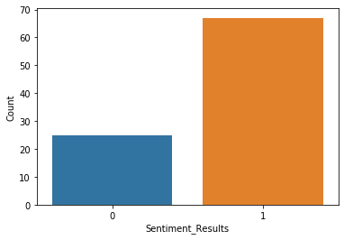

```python
sns.countplot('Analysis', data=df_snt)
_ = plt.xlabel('Sentiment_Results')
_ = plt.ylabel('Count')
plt.show()
```

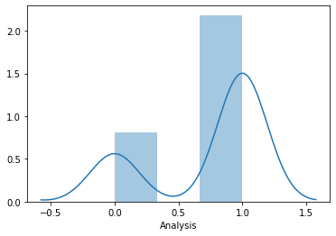

```python
sns.distplot(df_snt['Analysis'])
```

## Sentiment dataSet splitting the data preparation for modeling and fitting the data

## Lie detection splitting the data preparation for modeling

```python
##Lie Detection

from sklearn.model_selection import train_test_split
import numpy as np
# Convert label back to int.
#df2['Analysis'] = df['Analysis'].astype('int')
# Split the data into train and test sets.
np.random.seed(220)
x_train, x_test, y_train, y_test = train_test_split(df_snt['review'], df_snt['lie'], test_size=0.33, random_state=50)

from sklearn.feature_extraction.text import TfidfVectorizer

tf = TfidfVectorizer(min_df=2, max_df=0.8, sublinear_tf=True, use_idf=True, stop_words='english')


# Count and transform the training and testing sets.
x_train_ld = tf.fit_transform(x_train)
x_test_ld = tf.transform(x_test)
```

## Linear model Model

```python
##Lie detection
from sklearn.svm import SVC
from sklearn.metrics import accuracy_score
#Printing the confusion matrix of our prediction
from sklearn.metrics import confusion_matrix
from sklearn import metrics

# Now to use an svm to create the model.
model1_ld = LinearSVC()
model1_ld.fit(x_train_ld, y_train)

result1_ld = model1_ld.predict(x_test_ld)
print(result1_ld)

print('SVM Accuracy: %s ' % (accuracy_score(y_test, result1_ld)))

# print the confusion matrix
metrics.confusion_matrix(y_test, result1_ld)
```

[output not shown]

```
array([[13,  1],
       [ 3, 14]], dtype=int64)
```

```python
from sklearn.naive_bayes import MultinomialNB

# Now to use an svm to create the model.
Mul_model1_ld = MultinomialNB()
Mul_model1_ld.fit(x_train_ld, y_train)

result1_ld = model1_ld.predict(x_test_ld)
print(result1_ld)

print('SVM Accuracy: %s ' % (accuracy_score(y_test, result1_ld)))

# print the confusion matrix
metrics.confusion_matrix(y_test, result1_ld)
```

[output not shown]

```
array([[13,  1],
       [ 3, 14]], dtype=int64)
```

```python
MNB_score_ld= cross_val_score(model1_ld,x_train_ld, y_train, cv=5)
MNB_score_ld.mean()
```

```
0.6871794871794872
```

## Bernoulli Model

```python
##sentiment
from sklearn.naive_bayes import BernoulliNB
Bern_clf_ld = BernoulliNB()
Bern_clf_ld.fit(x_train_ld, y_train)

Bern_result_ld = Bern_clf_ld.predict(x_test_ld)
print(Bern_result_ld)

print('Bern: %s ' % (accuracy_score(y_test, Bern_result_ld)))

metrics.confusion_matrix(y_test, Bern_result_ld)
```

[output not shown]

```
array([[11,  3],
       [ 2, 15]], dtype=int64)
```

# Lie detection Validation Score

```python
len_score_ld= cross_val_score(model1_ld,x_train_ld, y_train, cv=5)
len_score_ld.mean()
```

```
0.6871794871794872
```

```python
MNB_score_ld= cross_val_score(model1_ld,x_train_ld, y_train, cv=5)
MNB_score_ld.mean()
```

```
0.6871794871794872
```

```python
Bern_score_ld= cross_val_score(model1_ld,x_train_ld, y_train, cv=5)
Bern_score_ld.mean()
```

```
0.6871794871794872
```

## Sentiment Model

```python
##Sentiment

from sklearn.model_selection import train_test_split
import numpy as np
# Convert label back to int.
#df2['Analysis'] = df['Analysis'].astype('int')
# Split the data into train and test sets.
np.random.seed(220)
x_train, x_test, y_train, y_test = train_test_split(df_snt['review'], df_snt['sentiment'], test_size=0.33, random_state=50)

from sklearn.feature_extraction.text import TfidfVectorizer

tf = TfidfVectorizer(min_df=2, max_df=0.8, sublinear_tf=True, use_idf=True, stop_words='english')


# Count and transform the training and testing sets.
x_train_snt = tf.fit_transform(x_train)
x_test_snt = tf.transform(x_test)
```

```python
##sentiment
from sklearn.svm import SVC
from sklearn.metrics import accuracy_score
#Printing the confusion matrix of our prediction
from sklearn.metrics import confusion_matrix
from sklearn import metrics

# Now to use an svm to create the model.
model1_snt = LinearSVC()
model1_snt.fit(x_train_snt, y_train)

result1_snt = model1_ld.predict(x_test_snt)
print(result1_snt)

print('SVM Accuracy: %s ' % (accuracy_score(y_test, result1_snt)))

# print the confusion matrix
metrics.confusion_matrix(y_test, result1_snt)
```

[output not shown]

```
array([[13,  1],
       [ 3, 14]], dtype=int64)
```

```python
from sklearn.naive_bayes import MultinomialNB

# Now to use an svm to create the model.
Mul_model1_snt = MultinomialNB()
Mul_model1_snt.fit(x_train_snt, y_train)

result1_snt = model1_snt.predict(x_test_snt)
print(result1_snt)

print('MNB Accuracy: %s ' % (accuracy_score(y_test, result1_ld)))

# print the confusion matrix
metrics.confusion_matrix(y_test, result1_snt)
```

```
['n' 'n' 'n' 'n' 'n' 'p' 'n' 'p' 'p' 'p' 'n' 'n' 'p' 'n' 'p' 'n' 'n' 'n'
 'p' 'p' 'p' 'p' 'p' 'n' 'n' 'n' 'n' 'p' 'p' 'p' 'p']
MNB Accuracy: 0.8709677419354839
```

```
array([[13,  1],
       [ 3, 14]], dtype=int64)
```

```python
##sentiment
from sklearn.naive_bayes import BernoulliNB
Bern_clf_snt = BernoulliNB()
Bern_clf_snt.fit(x_train_snt, y_train)

Bern_result_snt = Bern_clf_snt.predict(x_test_snt)
print(Bern_result_snt)

print('Bern: %s ' % (accuracy_score(y_test, Bern_result_snt)))

metrics.confusion_matrix(y_test, Bern_result_snt)
```

```
['n' 'n' 'n' 'p' 'n' 'p' 'n' 'p' 'p' 'p' 'n' 'n' 'p' 'n' 'p' 'p' 'n' 'n'
 'p' 'p' 'p' 'p' 'p' 'n' 'n' 'n' 'p' 'p' 'p' 'p' 'p']
Bern: 0.8387096774193549
```

```
array([[11,  3],
       [ 2, 15]], dtype=int64)
```

## Sentiment Validation Score

```python
len_score_snt= cross_val_score(model1_snt,x_train_snt, y_train, cv=5)
len_score_snt.mean()
```

```
0.6871794871794872
```

```python
MNB_score_snt= cross_val_score(model1_snt,x_train_snt, y_train, cv=5)
MNB_score_snt.mean()
```

```
0.6871794871794872
```

```python
Bern_score_snt= cross_val_score(Bern_clf_snt,x_train_snt, y_train, cv=5)
Bern_score_snt.mean()
```

```
0.7205128205128204
```

## CONCLUSION¶

Sentiment analysis is a task often utilized with text mining. The ability to predict sentiment from a given text is often invaluable for organizations. By integrating a feedback system from customers, an organization can determine preferences for various products. Moreover, having this knowledge can better prepare a supply chain by ensuring products are properly distributed across warehouses.

Though lie detection is often more difficult to ascertain than sentiment, the added information can supplement decision factors. For example, if a lie detection classifier has high predictive qualities, then noisy data (untruthful reviews) can be omitted from the successive analysis.

This allows descriptive analysis as well as classifier(s) to generalize and increase awareness. Overall, utilizing both lie detection and sentiment analysis for reviews can provide functional information needed for decision making.